# Coursework Report

*N* removed NAs: 3

*N* removed <18: 24

[output not shown]

**Main analysis results**

# Coursework Report

Analysing Data, Spring 2020

[output not shown]

[output not shown]

```
## [1] 3
```

```
## .
## 10 11 13 14 15 16 17 18 19 20 21 22 23 24 25 26 28
##  1  1  1  1  4  4 12 18 17 23 23 18 14  5  3  1  1
```

```
## [1] "numeric"
```

```
## .
##      control experimental
##           72           75
```

```
## tibble [147 x 6] (S3: tbl_df/tbl/data.frame)
##  $ ID        : Factor w/ 150 levels "AFBH","AJPK",..: 16 5 100 67 27 43 8 83 128 130 ...
##  $ YEARS     : num [1:147] 18 20 19 19 18 17 20 18 20 18 ...
##  $ CONDITION : Factor w/ 2 levels "control","experimental": 2 2 2 2 2 2 2 2 2 2 ...
##  $ QUESTION_1: num [1:147] 7 6 4 7 5 6 5 4 5 8 ...
##  $ QUESTION_2: num [1:147] 5 6 3 2 6 6 6 9 5 4 ...
##  $ QUESTION_3: num [1:147] 6 6 6 6 6 7 4 7 3 3 ...
```

```
## [1] 24
```

```
## # A tibble: 1 x 4
##    mean    sd   min   max
##   <dbl> <dbl> <dbl> <dbl>
## 1  20.8     2    18    28
```

```
## # A tibble: 1 x 4
##    mean    sd   min   max
##   <dbl> <dbl> <dbl> <dbl>
## 1  20.8     2    18    28
```

| CONDITION | n | perc | mean_age | sd_age |
| --- | --- | --- | --- | --- |
| control | 63 | 51.21951 | 20.8254 | 1.913784 |
| experimental | 60 | 48.78049 | 20.7500 | 2.104273 |

Table 1 *Descriptive statistics by Colour Condition*

| CONDITION | *N* | % | *M*<sub>age</sub> | *SD*<sub>age</sub> |
| --- | --- | --- | --- | --- |
| control | 63 | 51.22 | 20.83 | 1.91 |
| experimental | 60 | 48.78 | 20.75 | 2.10 |

```
## # A tibble: 123 x 5
##    ID    QUESTION_1 QUESTION_2 QUESTION_3 attract_comp
##    <fct>      <dbl>      <dbl>      <dbl>        <dbl>
##  1 CMTZ           7          5          6         5.96
##  2 BEXI           6          6          6         5.96
##  3 RWVN           4          3          6         5.96
##  4 LUEC           7          2          6         5.96
##  5 DTBE           5          6          6         5.96
##  6 BKPG           5          6          4         5.96
##  7 PEEL           4          9          7         5.96
##  8 VRXR           5          5          3         5.96
##  9 VSDT           8          4          3         5.96
## 10 JQDE           7          6          6         5.96
## # ... with 113 more rows
```

```
## # A tibble: 123 x 5
##    ID    QUESTION_1 QUESTION_2 QUESTION_3 attract_comp
##    <fct>      <dbl>      <dbl>      <dbl>        <dbl>
##  1 CMTZ           7          5          6         5.96
##  2 BEXI           6          6          6         5.96
##  3 RWVN           4          3          6         5.96
##  4 LUEC           7          2          6         5.96
##  5 DTBE           5          6          6         5.96
##  6 BKPG           5          6          4         5.96
##  7 PEEL           4          9          7         5.96
##  8 VRXR           5          5          3         5.96
##  9 VSDT           8          4          3         5.96
## 10 JQDE           7          6          6         5.96
## # ... with 113 more rows
```

```
## # A tibble: 123 x 5
## # Groups:   ID [123]
##    ID    QUESTION_1 QUESTION_2 QUESTION_3 attract_comp
##    <fct>      <dbl>      <dbl>      <dbl>        <dbl>
##  1 CMTZ           7          5          6         6
##  2 BEXI           6          6          6         6
##  3 RWVN           4          3          6         4.33
##  4 LUEC           7          2          6         5
##  5 DTBE           5          6          6         5.67
##  6 BKPG           5          6          4         5
##  7 PEEL           4          9          7         6.67
##  8 VRXR           5          5          3         4.33
##  9 VSDT           8          4          3         5
## 10 JQDE           7          6          6         6.33
## # ... with 113 more rows
```

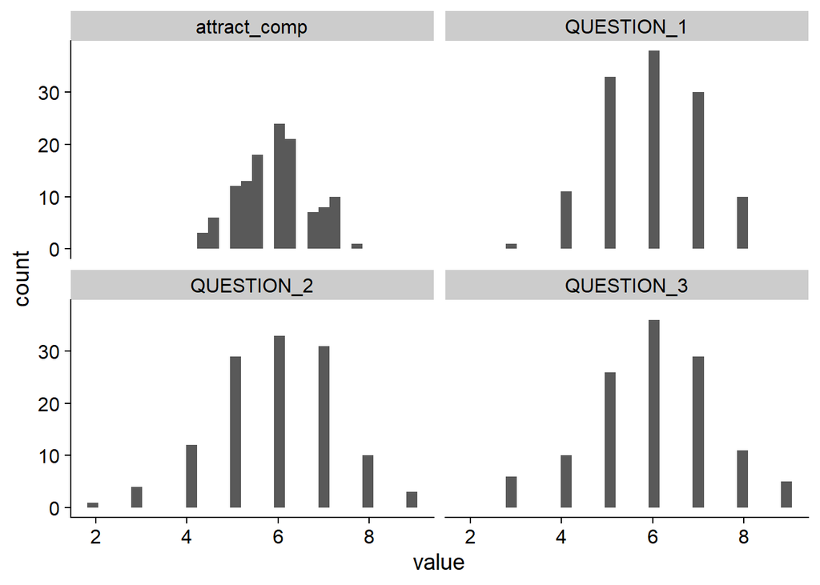

```
##
##  Pearson's product-moment correlation
##
## data:  data$QUESTION_1 and data$QUESTION_2
## t = 0.1416, df = 121, p-value = 0.8876
## alternative hypothesis: true correlation is not equal to 0
## 95 percent confidence interval:
##  -0.1645377  0.1894742
## sample estimates:
##       cor
## 0.0128716
```

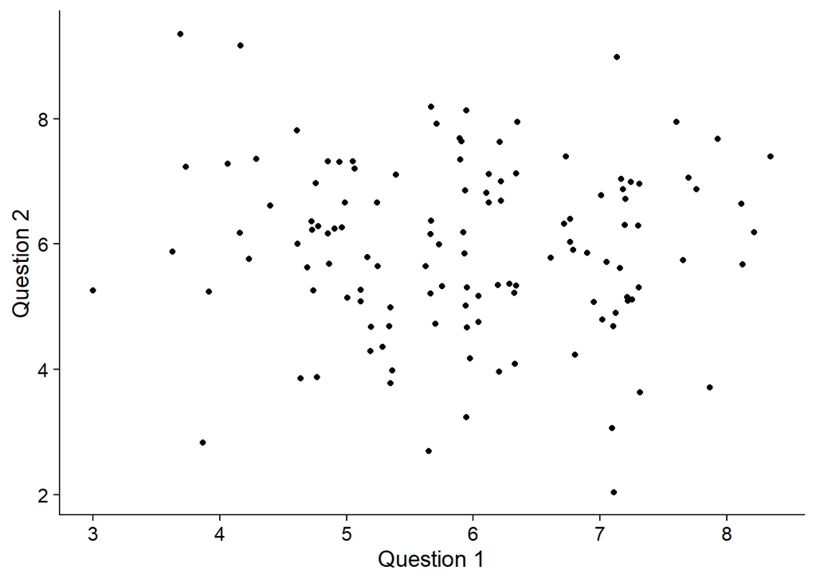

```
##            QUESTION_1 QUESTION_2 QUESTION_3
## QUESTION_1       1.00       0.01      -0.04
## QUESTION_2       0.01       1.00       0.10
## QUESTION_3      -0.04       0.10       1.00
##
## n= 123
##
##
## P
##            QUESTION_1 QUESTION_2 QUESTION_3
## QUESTION_1            0.8876     0.6532
## QUESTION_2 0.8876                0.2938
## QUESTION_3 0.6532     0.2938
```

[figure not shown]

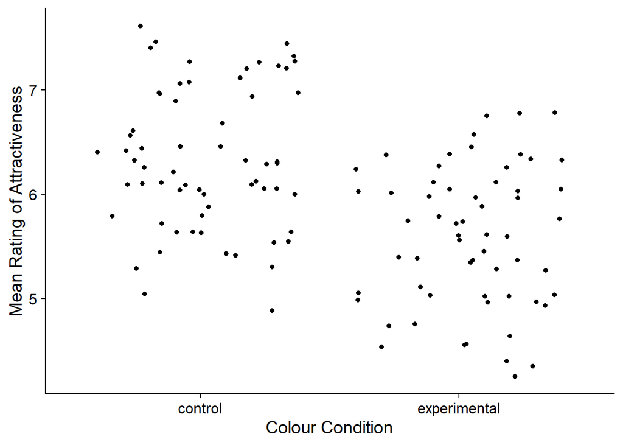

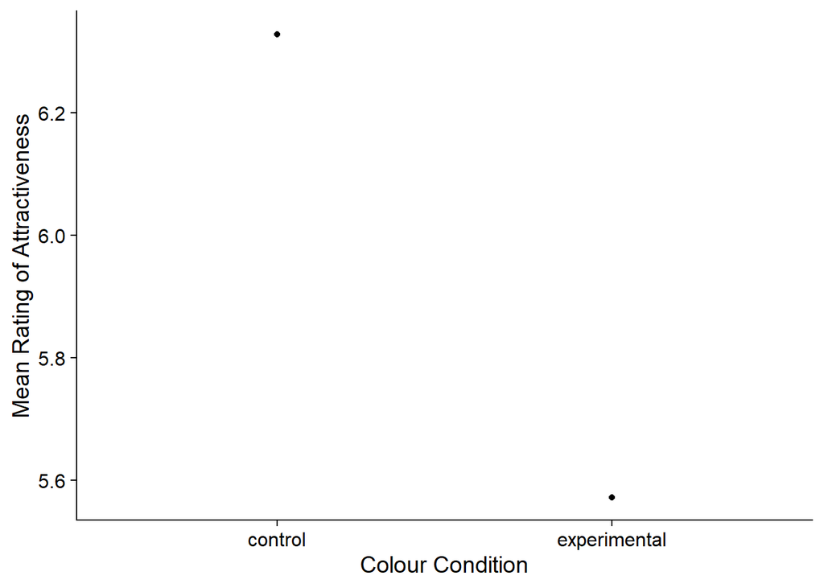

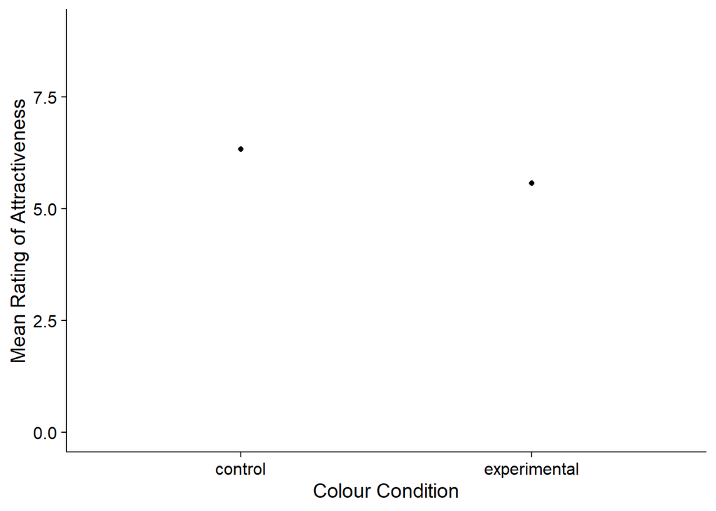

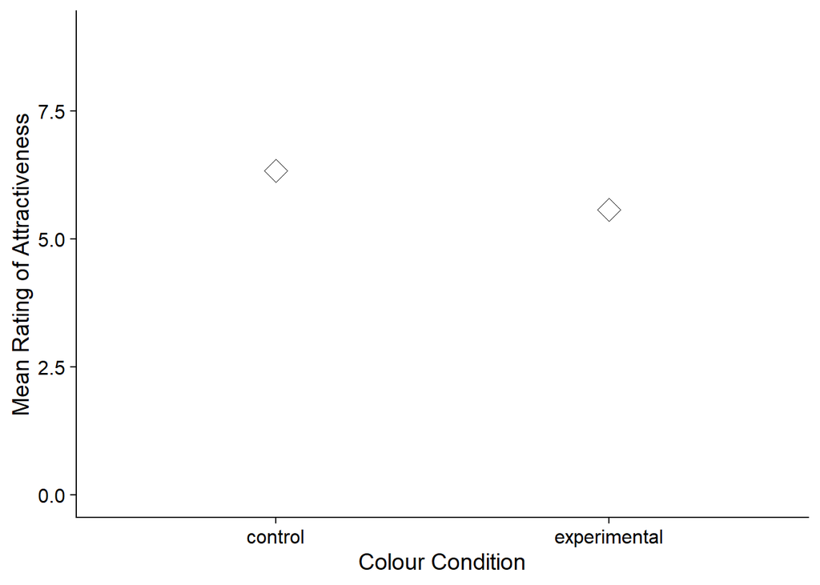

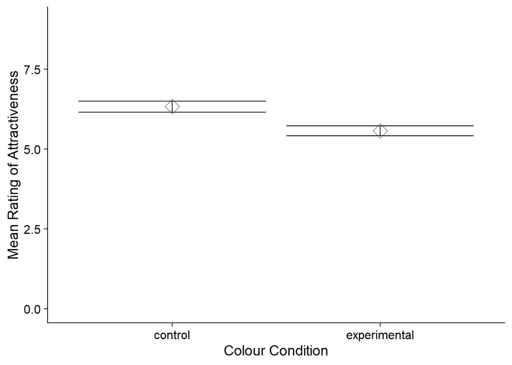

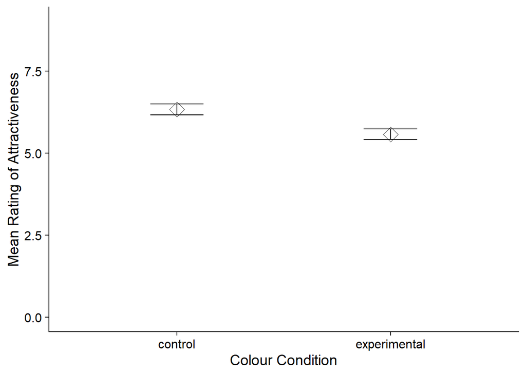

```
##
##  Two Sample t-test
##
## data:  QUESTION_1 by CONDITION
## t = 0.97413, df = 121, p-value = 0.3319
## alternative hypothesis: true difference in means is not equal to 0
## 95 percent confidence interval:
##  -0.2048312  0.6016566
## sample estimates:
##      mean in group control mean in group experimental
##                   6.031746                   5.833333
```

# Methods

## Participants

Initially, the number of individuals who participated in the study came to a sum of 150 participants. However, once the data was cleaned, 27 participants were removed. This was due to 3 participants providing N/A answers regarding their age, leaving their data incomplete, and 24 participants being under the age of 18. These individuals were removed due to ethical concerns as children are not able to provide complete, informed consent. This left 123 participants whose data was included in the results. The mean age of participants was 20.79 and the standard deviation of the participants’ ages was 2. The maximum age of participants was 28 and the minimum age was 18, creating an age range of 10 years.

Table 1 *Descriptive statistics by Colour Condition*

| CONDITION | *N* | % | *M*<sub>age</sub> | *SD*<sub>age</sub> |
| --- | --- | --- | --- | --- |
| control | 63 | 51.22 | 20.83 | 1.91 |
| experimental | 60 | 48.78 | 20.75 | 2.10 |

## Design

The conceptual hypothesis for this experiment was ‘Does colour influence attractiveness?’. The predictor was colour and the outcome was attractiveness. The experiment used a between-subjects design which allowed the independent categorical variable of colour to be operationalised through two levels of coloured frames. The participant would see one of two pictures presented in a frame, with the control condition being shown an achromatic white frame, and the experimental condition being show a chromatic red frame. Attractiveness was the dependent variable and this was operationalised through ratings on a 1-9 Likert scale (higher score = more attractive), consisting of three questions, which was presented to participants after seeing the pictures of the men. Question 1 was “How attractive do you think this person is?”, Question 2 was “How pleasant is this person to look at?” and finally Question 3 was “If I were to meet the person in this picture face to face, I would think he is attractive” (Elliot et al, 2010). The answers to these questions were then averaged together to get a composite score. Therefore, the operational hypothesis for this experiment is “Does viewing a different colour frame around a picture of a moderately attractive male influence the mean ratings of his attractiveness?”. This hypothesis will be tested through the use of a t-test in statistical analysis.

# Results

When reviewing the composite scores for the two experimental conditions, it shows the control (white frame) condition to provide a slightly higher rating of attractiveness (M = 6.33, SD = 0.69) when compared to the experimental condition (M = 5.57, SD = 0.66). However, the control condition also has the largest spread of data, shown by its standard deviation. This suggests that the participants’ ratings of attraction varied more in the control condition but were more similar and clustered around the mean in the experimental condition. Although this difference in standard deviation is slight, it may show that the colour red provides more consistent attractiveness ratings than an achromatic colour. The composite score is the mean of each participant’s scores on the three questions on the 1-9 Likert scale. This provides a average measurement of attractiveness. This immediately suggests that the results may support the hypothesis because there is a difference between the experimental and control colour condition. However, because the achromatic condition has provided higher attractiveness ratings, it hints that the colour red may not influence attraction. These results are demonstrated in the table below that shows the descriptive statistics of attractiveness by colour condition in the experiment.

```
## # A tibble: 1 x 4
##    mean    sd   min   max
##   <dbl> <dbl> <dbl> <dbl>
## 1  5.96  0.77  4.33  7.67
```

```
## # A tibble: 1 x 4
##    mean    sd   min   max
##   <dbl> <dbl> <dbl> <dbl>
## 1  5.96  0.77  4.33  7.67
```

| CONDITION | n | perc | mean_attract_comp | sd_attract_comp |
| --- | --- | --- | --- | --- |
| control | 63 | 51.21951 | 6.328042 | 0.6917125 |
| experimental | 60 | 48.78049 | 5.572222 | 0.6555332 |

Table 1 *Descriptive statistics of Attractiveness by Colour Condition*

| Condition | *N* | % | *M*<sub>Attractiveness</sub> | *SD*<sub>Attractiveness</sub> |
| --- | --- | --- | --- | --- |
| control | 63 | 51.22 | 6.33 | 0.69 |
| experimental | 60 | 48.78 | 5.57 | 0.66 |

The relationship between colour condition and attractiveness ratings is illustrated in the graph below.

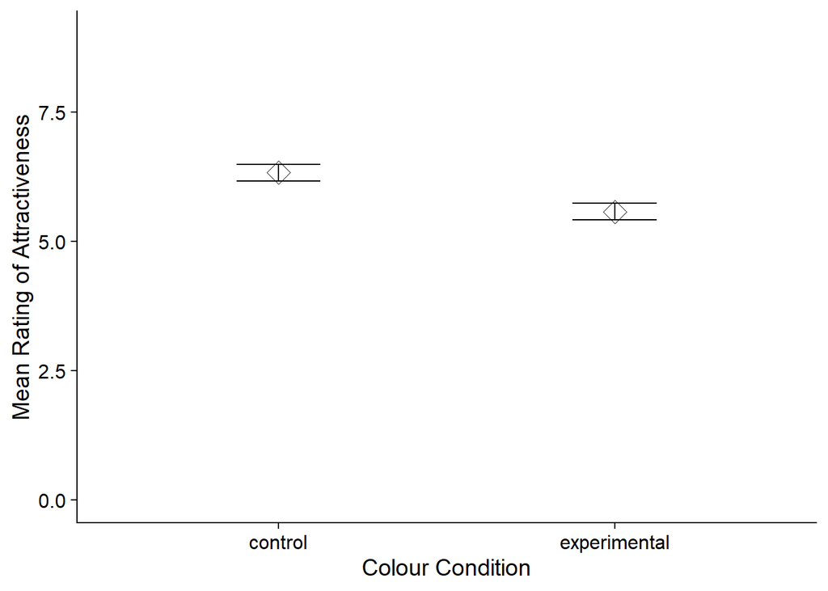

# Discussion

The results of this study demonstrate that colour does influence attractiveness, however in this case, the control group, who were showed a white frame, reported higher ratings of attractiveness than the experimental, red frame condition. This suggests that colour had a negative effect on attractiveness ratings rather than enhancing them. This data was collected from 123 participants with a mean age of 20.79 years (SD = 2). These results are different from the original study as Elliot (2010) found that participants in the red condition rated the target men as more attractive when compared to the white control condition (Elliot et al, 2010). This means that the findings from these two results do not support each other. This has a negative impact on the effect being studied as the focus was on whether red does evoke men to be perceived more attractive than other colours. This weakens the reliability of the ‘Red effect’ (Peperkoorn et al, 2016) as this replication study has not supported previous research findings that have demonstrated a positive correlation between the colour red and percieved male attractiveness. In previous research, the colour red has been found to connote romance and passion cross-culturally, however this only appears to spark significance within heterosexual relationships (Aslam, 2006; Neto, 2002). Red has also been specifically associated with sexual allurement (Elliot, A.J. & Niesta, D. 2008) which is regarded as a key component of attraction. Therefore, with consideration of this previous body of research, it would be expected for our study to conform to a similar pattern of results. However, the results collected in this particular study do not find that women find men more attractive when in conjunction with the colour red, and therefore do not support the effect found in other studies. This highlights that the effect of red on male perceived attractiveness may not be as reliable as previously portrayed due to these results being incompatible, however this would need to be repeated and investigated further in order to make a confident judgement on the effect.

The design used for this experiment was a between-subject design where participants were randomly assigned to one of two conditions. Although this design required a larger quantity of participants, it ensured that order effects were avoided as each participant was only required to take part in one condition. This attempted to optimise the individual’s attention and to reduce fatigue and boredom from interfering with results. There’s risk for potential individual differences within the control and experimental conditions to impact results, however these participant variables were overcome through the random allocation of participants as this reduces the chance of systematic error. The nature of this study is a lab experiment. This crafts a slightly artificial setting however it allows for a far more controlled environment, that facilitates the control of potential extraneous variables, such as any visual distractions. This experimental method also maintains a clear manipulation of the independent variable colour which ensures a high degree of causality to be drawn from the results due to the high control of variables. Finally, the methods used are standardized which means the procedures can be easily replicated. This provides a foundation for future research as the methods can be repeated which perpetuates this experiment’s reliability. There was an initial ethical concern because there were 24 participants that were under the age of 18 years old. This caused complications regarding consent as individuals regarded as children are not able to give complete, informed consent. However, this was overcome by removing these individual’s and their results from the experiment’s data to avoid any ethical issues. A further 3 participants had to also be removed due to giving N/A answers, leaving their results incomplete. This meant that the sample for this experiment was reduced to 123 female participants with a mean age of 20.79 years (SD = 2). This provides an insight into the attraction pattern of this particular demographic of women, however this means that this study may only be representative of this sample. This sparks interest for further research to focus on a wider range of age groups. This would test whether the influence of colour on attraction is more impactful for certain age groups more than others, and to see whether the relationship of colour and attraction changes over time.

Despite the results of this particular study suggesting that the colour red does not promote attraction, it is still clear that red plays a role in perceived male attraction as the previous body of research cannot be ignored. The “Red effect” is an extensively researched effect that has found relevance in both human and animal kingdoms. For example, mating preference in favour of males exhibiting the colour red has been demonstrated in nonhuman primates such as rhesus macaques (Waitt et al., 2003). This highlights the generalisability of this effect, so regardless of the outcome of our study, the red effect still holds significance surrounding the concept of attraction. However, due to the results of this study, it must be recognised that the reliability of this effect may not be as strong as once presumed. Therefore, further research will need to be conducted in order to establish consistency regarding the “Red Effect”.

The research question of whether colour influences attraction should certainly be investigated further, perhaps experimenting with other colours to see whether attraction is exclusively enhanced by red. This would provide a platform to explore whether other colours evoke or reduce attractiveness ratings. This would widen our understanding of the role of colour in attraction, which can subsequently provide application to the likes of human dating and personal relationships, which is are hugely relevant mechanisms in society. A follow-up study may prove useful in terms of elaborating the measurement of attraction. This is because this study only included 3 questions, which slightly simplifies the vast abstract concept of attraction, so future research could explore more items when questioning participants about the men in the picture. Attraction could be divided into more detailed sub-units such as sexual attraction (Schwarz & Singer, 2013), and apply a different range of questions to assess this, and loyalty (Peperkoorn, Roberts & Pollet, 2016), as these are key attributes associated with perceived attractiveness. This would a more detailed overview of attraction.

In conclusion, this study did not support the notion of the colour red enhancing attraction, in fact it highlighted that red had a more negative impact on attraction. This was demonstrated through the white control group having a higher average attractiveness score. Despite this, the “Red Effect” is a widely recognised influence when regarding romance so this effect still remains relevant. This study reiterates the importance of replicating studies, as results are not always consistent with previous research. This crafts an extensive body of data that can be used to assess the strength and reliability of such effects. This experiment has highlighted inconsistency in the “Red effect” but by no means disproves it.

# References

Aslam, M. M. (2006). Are you selling the right colour? A cross-cultural review of colour as a marketing cue. Journal of Marketing Communi- cations, 12, 15–30.

Elliot, A. J., Kayser, D. N., Greitemeyer, T., Lichtenfeld, S., Gramzow, R. H., Maier, M. A., & Lui, H. (2010). Red, rank, and romance in women viewing men. Journal of Experimental Psychology: General, 139(3), 399-417. Doi:10.1037/a0019689

Elliot, A. J., & Niesta, D. (2008). Romantic red: Red enhances men’s attraction to women. Journal of Personality and Social Psychol- ogy, 95, 1150–1164. doi:10.1037/0022-3514.95.5.1150

Neto, F. (2002). Colors associated with styles of love. Perceptual and Motor Skills, 94, 1303–1310.

Peperkoorn, L. S., Roberts, S. C., & Pollet, T. V. (2016) Revisiting the Red Effect on Attractiveness and Sexual Receptivity. Evolutionary Psychology, 14(4), 147470491667384. doi:10.1177/1474704916673841

Schwarz, S., & Singer, M. (2013). Romantic red revisited: Red enhances men’s attraction to young, but not menopausal women. Journal of Experimental Social Psychology, 49, 161–164. doi:10. 1016/j.jesp.2012.08.004

Waitt, C., Little, A. C., Wolfensohn, S., Honess, P., Brown, A. P., Buchanan- Smith, H. M., & Perrett, D. I. (2003). Evidence from rhesus macaques suggests male coloration plays a

role in female primate mate choice. Proceedings of the Royal Society, Series B, 270(Suppl.), 144–146.